# INFSCI 2595 Final Project

Part 3B, Classification - Bayesian Analysis

Zhenyu Li

2022-04-22

```r
library(tidyverse)
theme_set(theme_linedraw())
library(rstanarm)
options(mc.cores = parallel::detectCores())
library(corrplot)
source("./scripts/utils.R")
```

```r
df <- readr::read_csv("./data/final_project_train.csv", col_names = TRUE)
sel_num <- df %>% select_if(is_double) %>% select(!rowid) %>% select(sort(names(.))) %>% colnames()
sel_num_in <- setdiff(sel_num, "response")
sel_cat <- df %>% select(!one_of(sel_num)) %>% select(!rowid) %>% colnames()
sel_cat_in <- setdiff(sel_cat, "outcome")
```

In this section, I will use Bayesian approach to evaluate 3 baseline logistic models with relatively good performance from section 3A.

## Preprocessing

- For classification, the necessary preprocessing steps include:
  - Normalize the continuous inputs

```r
df_prep_cl <- df %>%
  mutate_if(is.character,as.factor) %>%
  select(-c(rowid,response)) %>%
  mutate(
    across(starts_with("x"), scale)
  ) %>%
  mutate(outcome = ifelse(outcome=="event",1,0))
```

## Bayesian Model Fitting

**Select 3 models from 3A for Bayesian model fitting.**

- Based on the best BIC, select `mod_3A2`. This is also the simplest model among these three.
- Based on balance of the two, select `mod_3A3`. This model adds categorical inputs.
- Based on the best AIC, select `mod_3Ac2`.
- I will use a medium prior for all models.

```r
mod_3A2 <- readr::read_rds("models/mod_3A2")
mod_3A3 <- readr::read_rds("models/mod_3A3")
mod_3Ac2 <- readr::read_rds("models/mod_3Ac2")
```

**1. Based on model `mod_3A2`, linear additive of continuous inputs only.**

```r
mod_3B1_3A2 <- stan_glm(
  mod_3A2$call$formula,
  data = df_prep_cl %>% select(-all_of(sel_cat_in)),
  family = binomial,
  prior = normal(0,2.5),
  seed = 1324
)
```

**2. Based on model `mod_3A3`, linear additive of all inputs.**

```r
mod_3B2_3A3 <- stan_glm(
  mod_3A3$call$formula,
  data = df_prep_cl,
  family = binomial,
  prior = normal(0,2.5),
  seed = 1324
)
```

**3. Based on model `mod_3Ac2` where some inputs are interacted.**

```r
mod_3B3_3Ac2 <- stan_glm(
  mod_3Ac2$call$formula,
  data = df_prep_cl,
  family = binomial,
  prior = normal(0,2.5),
  seed = 1324
)
```

Save the 3 models to file.

```r
my_models <- mget(ls(pattern = "^mod_3B"))
save_models(my_models)
```

## Conclusions

```r
mod_3B1_3A2 <- readr::read_rds("models/mod_3B1_3A2")
mod_3B2_3A3 <- readr::read_rds("models/mod_3B2_3A3")
mod_3B3_3Ac2 <- readr::read_rds("models/mod_3B3_3Ac2")
```

### Model Comparison

**Compare models based on information criterion.**

```r
mod_3B1_3A2$waic <- waic(mod_3B1_3A2)
mod_3B2_3A3$waic <- waic(mod_3B2_3A3)
mod_3B3_3Ac2$waic <- waic(mod_3B3_3Ac2)
my_models <- stanreg_list(
  mod_3B1_3A2, mod_3B2_3A3, mod_3B3_3Ac2,
  model_names = c("3B1_3A2, all continuous","3B2_3A3, all inputs","3B3_3Ac2, interactions"))
loo_compare(my_models, criterion = "waic")
```

```
## Model comparison based on WAIC:
##                         elpd_diff se_diff
## 3B2_3A3, all inputs      0.0       0.0
## 3B3_3Ac2, interactions  -1.3       5.4
## 3B1_3A2, all continuous -2.7       5.2
```

- Based on WAIC, the three models really do not have much performance differences (difference within standard error).
- Thus the simplest model, 3B1_3A2, where only have the continuous inputs linear added, should be picked as the best model.

### Best Model

**Analyze the posterior behavior of the best model.**

#### Coefficients

**Visualize posterior regression coefficient plot.**

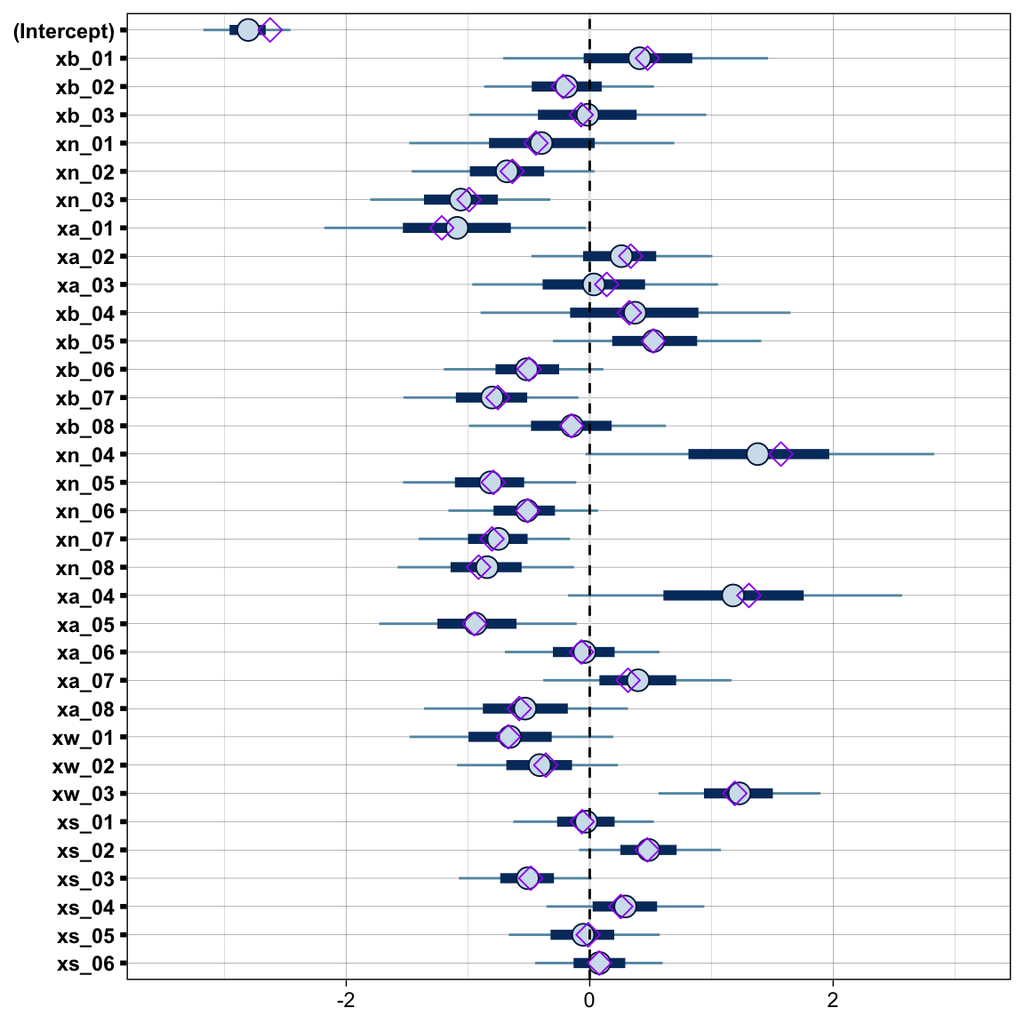

```r
plot(mod_3B1_3A2, pars = names(mod_3B1_3A2$coefficients)) +
  geom_vline(xintercept = 0, color = "black", linetype = "dashed", size = 0.5) +
  geom_point(
    data = as_tibble(coef(mod_3A2), rownames="coef"), aes(x = value, y = coef),
    shape = 5,
    size = 3,
    color = "purple"
    )
```

- The MLE estimated coefficients are plotted using purple diamonds.
- We see the prior slightly constrained most of the coefficients.

**Check the correlation of the posterior coefficients.**

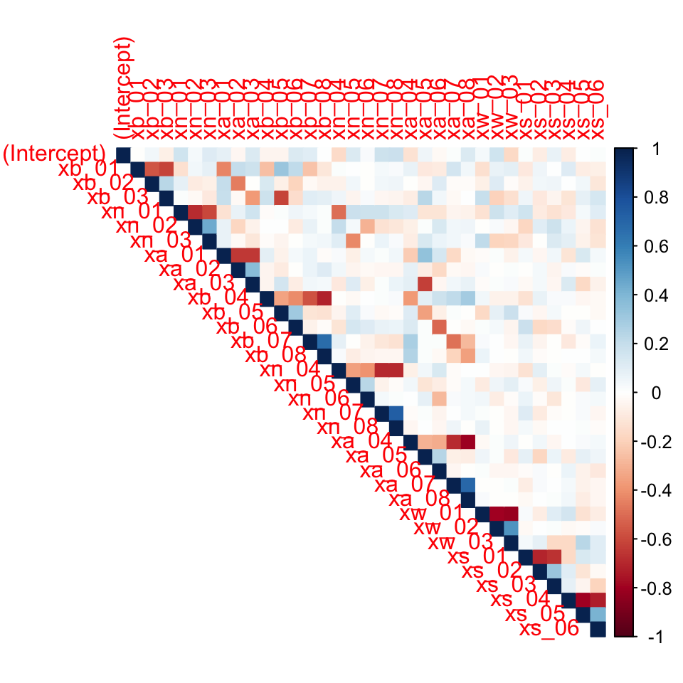

```r
mod_3B1_3A2 %>% as_tibble() %>%
  select(all_of(names(mod_3B1_3A2$coefficients))) %>%
  cor() %>% corrplot(method="color", type="upper")
```